[figure not shown]

# Public Option Premium Change Illustration By Rating Area

- Robin Wang
- Wednesday, Aug 26, 2020

[figure not shown]

# Illustrate Federal Premium Spending Impact of Public Option Policy Interventions

- Explore impact of differential urban/rural health provider rate changes
- Construct Health Insurance Rating Areas based on Sub-State Units & Rating Rules
- Automate a mapping pipeline of policy impact visualization

## 1. Policy Take-aways Illustrated

Public options, a closely evaluated health policy intervention by the public sector to spur provider competition and patient savings, could take many forms in the US health system.

Interactions between providers and health plan carriers are shaped by competitive landscapes on either end, while different dimensions of health care service / spending have different potentials for reimbursement oriented reforms.

### Regional Dynamics in Hospital and Physician Reimbursement Context

We explore a series of 7 illustrative scenarios, in which provider reimbursement rates would be subject to region specific cuts, and several levels of prescription drug savings are added for illustrative purposes.

| Scenario | Reforms |
| --- | --- |
| 1 | Standard Reimbursement Rate Reduction, plus 6.87% prescription drug spending savings |
| 2 | Standard Reimbursement Rate Reduction, plus 10.61% prescription drug spending savings |
| 3 | Scenario 1, plus further cuts in regions with one insurer |
| 4 | Scenario 1, plus further cuts in regions with two or fewer insurers |
| 5 | Scenario 1, 10% reimbursement boost for rural providers |
| 6 | Scenario 1, 15% reimbursement boost for all hospitals, and 10% boost for rural physicians |
| 7 | Scenario 6, except rural hospitals now given a 40% reimbursement boost |

### Synthesize Findings into a Spectrum of Visualized Illustrations

Behind this mildly satisfying animated illustration, it is important to note that such analysis would not be possible without first and foremost understanding and programmatically expressing the regulatory landscape of health insurance rating rules across states. This, we shall explore in part 2 below.

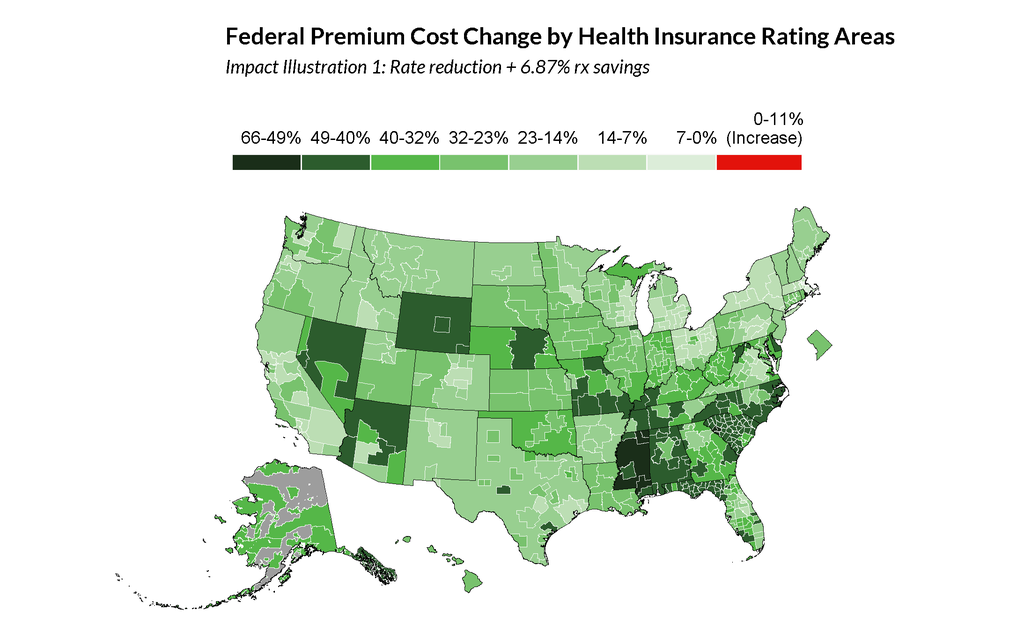

## 2. Mapping Local Health Insurance Rating Rules in the US

Efforts to bring visual clarity to the domain of health insurance rating areas have been frustrated by the inconsistency of geographic units in use for rating purposes, as well as the complexity of health insurance plan rating rules between states.

1. Accessing Census API Data for Health Insurance Rating Area Construction
- Bespoke adjustments needed to address Kusilvak and Oglala, for cross walk with HHS Rating Area level designation

```r
counties <- tidycensus::get_acs(geography = "county", variables = "B19013_001",
                                geometry = TRUE) %>% arrange(NAME)
counties$NAME_orig <- counties$NAME

counties <- counties %>% separate(NAME, into = c("county", "state"),sep="\\,")
counties$state <- trimws(counties$state, which = c("left"))

# inspect states
unique(counties$state)

# Remove Puerto Rico
counties <- counties %>% filter(state != "Puerto Rico")
# Alaska
counties$county[counties$GEOID=="02158"] <- "Kusilvak, formerly Wade Hampton 02270"
# South Dakota
counties$county[counties$GEOID=="46102"] <- "Oglala Lakota County, formerly Shannon 46113"

unique(counties$state)
length(unique(counties$state))


# State Data, used for Alaska Cropping and state boundaries
states <- tidycensus::get_acs(geography = "state", variables = "B19013_001",
                                geometry = TRUE) %>% arrange(NAME)
states <- states %>% filter(NAME != "Puerto Rico")
colnames(states)[match("NAME",colnames(states))] <- "state"
```

- Differentiate State Rules Regarding Local Health Insurance Rating

```r
only1 <- c("Vermont","Rhode Island","New Jersey","Hawaii",
           "District of Columbia","Delaware","New Hampshire")

only1data_factory <- function(df,name) {
  statedata <- df %>% filter(state == name)
  group1 <- statedata$GEOID
  statedata <- statedata %>% mutate(group = case_when(GEOID %in% group1 ~ 'newgroup1',TRUE ~ GEOID))
  statedata2 <- group_by(statedata, group) %>% summarise(estimate=sum(estimate), do_union = TRUE)
  statedata_merge <- statedata2 %>% mutate(facet = "merged") %>% dplyr::select("group","estimate","facet","geometry")
  statedata_unmerge <- statedata %>% dplyr::select(group,estimate) %>% mutate(facet = "unmerge")
  statedata_output <- rbind(statedata_merge, statedata_unmerge)
  statedata_output$ratingarea <- 1
  statedata_output$state <- name
  statedata_output <- statedata_output %>% dplyr::select(-c("group"))
  statedata_output <- statedata_output[c("state","ratingarea","facet","estimate","geometry")]
  statedata_output$ratingarea <- as.factor(statedata_output$ratingarea)
  return(statedata_output)
  }

# Examine how many counties there are for benchmarking
other <- filter(counties,!(state %in% only1))["state"]
other <- unique(other$state)
other

county_counteur <- function(df,name) {
  statedata <- df %>% filter(state == name)
  count <- length(unique(statedata$county))
  return(list(name, count))
}

othercounties <- filter(counties,!(state %in% only1))
```

2. Going beyond Census API: Redraw Geographic Units for Alaska, California, Massachusetts & Nebraska

*States and Local Counties may use 3 or 5-digit zipcodes or other geographic designations to determine regions for health insurance regulation purposes.*

**Alaska**

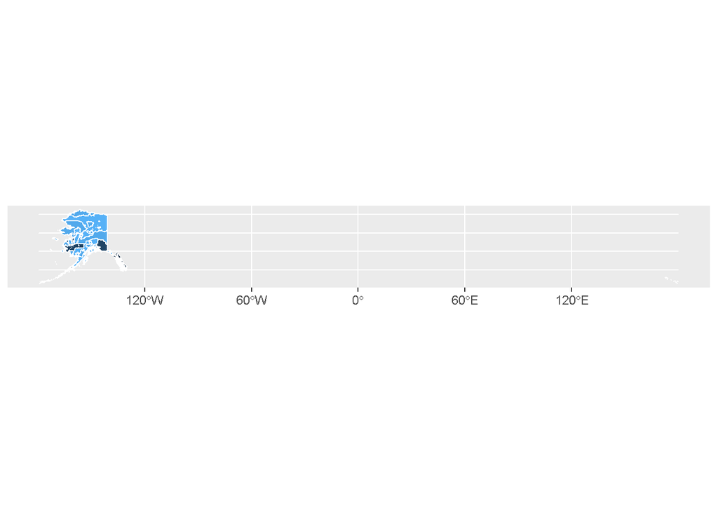

```r
ESRIshp <- st_read("data/SHP3-digitESRI/Export_3DigitShpAK.shp") %>%
  dplyr::select(ZIP3,STATE,Shape_Area,geometry)
ESRIshp <- ESRIshp %>% filter(ZIP3 %in% c("000","995","996","997","998","999"))
ESRIshp$STATE <- as.character(ESRIshp$STATE)
ESRIshp$ZIP3 <- as.character(ESRIshp$ZIP3)
# AK shape, to be used as clipper for 3 digit zip shape file
AK_state <- states %>% filter(state == "Alaska")

ESRIshp_AK <- st_transform(ESRIshp,st_crs(AK_state))
# st_crs(ESRIshp_AK)
# st_crs(AK_state)
ESRIshp_AK <- st_crop(ESRIshp_AK,AK_state)
colnames(ESRIshp_AK)[1] <- "zip3"

AKzip3_to_RA <- read_excel("data/AKzip3-RA-crosswalk.xlsx")
# Use left join to preserve large areas in AK without zip code assignment
AKshp <- left_join(ESRIshp_AK,AKzip3_to_RA,by="zip3")
AKshp$STATE <- "AK"
AKshp <- group_by(AKshp,RA) %>% summarise(estimate=sum(Shape_Area),do_union = TRUE)
AKshp$RA <- as.factor(AKshp$RA)

ggplot() +
  geom_sf(data = AKshp, aes(fill = estimate), color = 'white') +
  theme(legend.position = "none")
```

```r
rm(AK_state,AKzip3_to_RA,ESRIshp_AK)
```

**California - LA County**

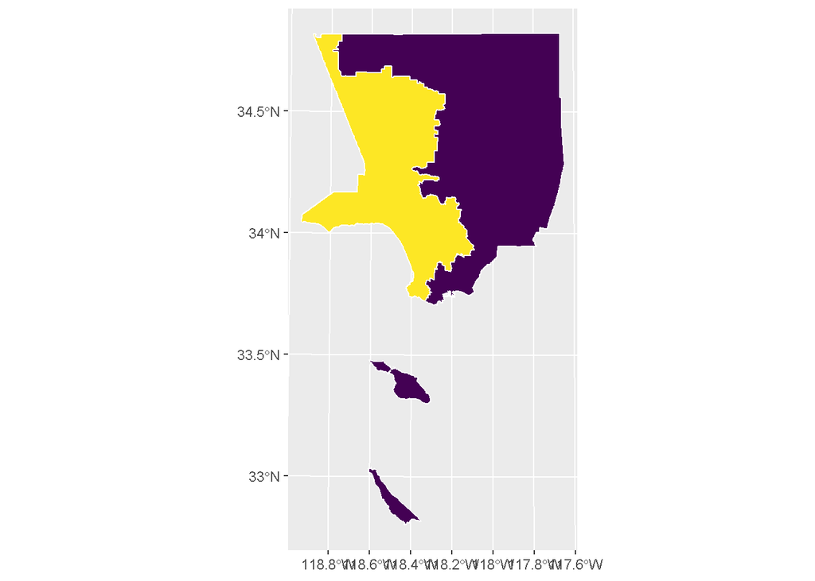

```r
CALAshp <-
  st_read("data/ZipCode_CA_LACounty/CAMS_ZIPCODE_PARCEL_SPECIFIC/CAMS_ZIPCODE_PARCEL_SPECIFIC.shp") %>%
  dplyr::select(ZIPCODE,OBJECTID,geometry)
CALAshp$group <- 1
CALAshp$zip3 <- substr(CALAshp$ZIPCODE,1,3)
# ggplot() + geom_sf(data = CALAshp, aes(fill = group), color = 'white') + scale_fill_viridis_c()

# Keeping lines below for referencing odd regional assignment, 928 and 923
# CALAshpmerge <- group_by(CALAshp,zip3) %>% summarise(estimate=sum(group), do_union = TRUE)
# ggplot() + geom_sf(data = CALAshpmerge, aes(fill = zip3), color = 'white')
# ggplot() + geom_sf(data = CALAshpmerge, aes(fill = zip3), color = 'white')
# CALAshpmerge %>% filter(zip3 == "928")%>% ggplot + geom_sf(aes(fill=zip3),color="white")
# CALAshpmerge %>% filter(zip3 == "923")%>% ggplot + geom_sf(aes(fill=zip3),color="white")

CALAzip3_to_RA <- read_excel("data/CALAzip3-RA-crosswalk.xlsx")
CALAshp <- merge(CALAshp,CALAzip3_to_RA,by="zip3")
CALAshp <- group_by(CALAshp,RA) %>% summarise(estimate=sum(group),do_union = TRUE)

CALAshp1 <- CALAshp
CALAshp1$state <- "California"
CALAshp1$do_union <- NULL
CALAshp1$facet <- "merged"
colnames(CALAshp1)[1] <- "ratingarea"
ggplot() + geom_sf(data = CALAshp1, aes(fill = estimate), color = 'white') +
  scale_fill_viridis_c() +
  theme(legend.position = "none")
```

```r
rm(CALAzip3_to_RA,CALAshp)
```

**Harmonize Refined LA County with the rest of the state..**

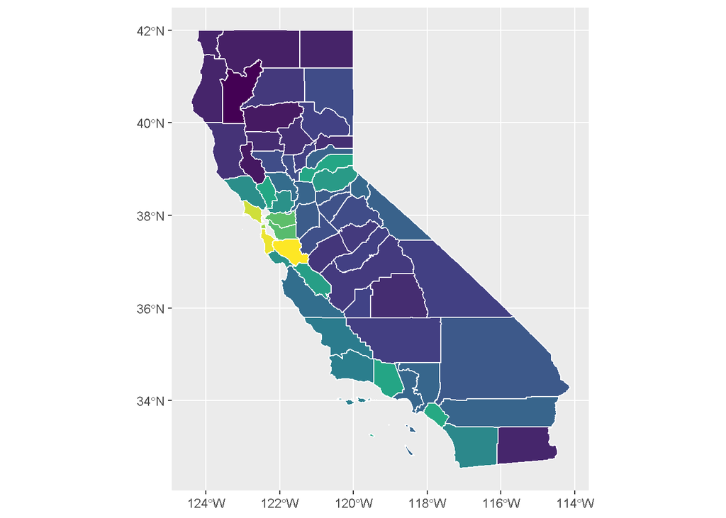

```r
CAOrig <- othercounties %>% filter(state == "California")
CALAOrig <- CAOrig %>% filter(GEOID == "06037")

# County CALA file has wrong crs, NEED RESET AND REPROJECT
# CALAshp1
CALAshp1 <- st_transform(CALAshp1,st_crs(CAOrig)$epsg)
# Drop LA County and Merge Edited
CAOrig$geometry[CAOrig$GEOID == "06037"] <- CALAshp1$geometry[CALAshp1$ratingarea==15]
CAOrig$county[CAOrig$GEOID == "06037"] <- "Los Angeles County - 15"
CAOrig$GEOID[CAOrig$GEOID == "06037"] <- "0603715"

CAmerge <- rbind(CAOrig,CALAOrig)
CAmerge$geometry[CAmerge$GEOID == "06037"] <- CALAshp1$geometry[CALAshp1$ratingarea==16]
CAOrig$county[CAOrig$GEOID == "06037"] <- "Los Angeles County - 16"
CAmerge$GEOID[CAmerge$GEOID == "06037"] <- "0603716"

ggplot() + geom_sf(data = CAmerge, aes(fill = estimate), color = 'white') +
  scale_fill_viridis_c() +
  theme(legend.position = "none")
```

```r
othercounties <- filter(othercounties, state!="California")
othercounties <- rbind(othercounties,CAmerge)
rm(CAOrig,CALAOrig,CAmerge)
```

**Massachusetts**

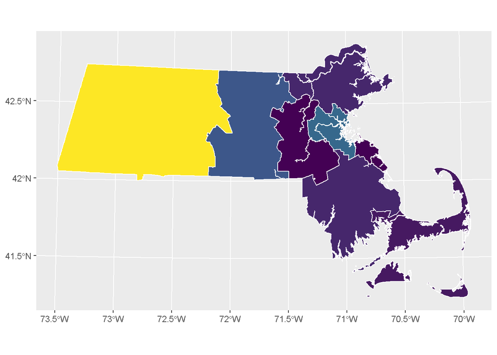

```r
MAshp <-
  st_read("data/zipcodes_MA/ZIPCODES_NT_POLY.shp") %>% dplyr::select(POSTCODE,PC_NAME,COUNTY,geometry)
MAshp1585 <- MAshp %>%
  filter(POSTCODE == "01585") %>% ms_filter_islands(min_area = units::set_units(1,km^2)) %>%
  drop_crumbs(set_units(5,km^2))
MAshp <- filter(MAshp,POSTCODE != "01585") %>% rbind(MAshp1585)

MAshp$group <- 1
MAshp$zip3 <- substr(MAshp$POSTCODE,1,3)
MAshp$zip3[MAshp$zip3 == "121"] <- "012"
MAshp2 <- group_by(MAshp,zip3) %>% summarise(estimate=sum(group),do_union = TRUE)
# ggplot() + geom_sf(data = MAshp2, aes(fill = estimate), color = 'white') + scale_fill_viridis_c()

MAzip3_to_RA <- read_excel("data/MAzip3-RA-crosswalk.xlsx")
# MAshp3 <- merge(MAshp2,MAzip3_to_RA,by="zip3") %>% dplyr::select(-c("do_union"))
MAshp3 <- merge(MAshp2,MAzip3_to_RA,by="zip3")

MAshp3 <- group_by(MAshp3,RA) %>%
  summarise(estimate=sum(estimate),do_union = TRUE) %>%
  fill_holes(threshold = units::set_units(200,km^2))

ggplot() + geom_sf(data = MAshp3, aes(fill = estimate), color = 'white') +
  scale_fill_viridis_c() +
  theme(legend.position = "none")
```

```r
rm(MAshp1585,MAshp,MAshp2,MAzip3_to_RA)
```

**Nebraska**

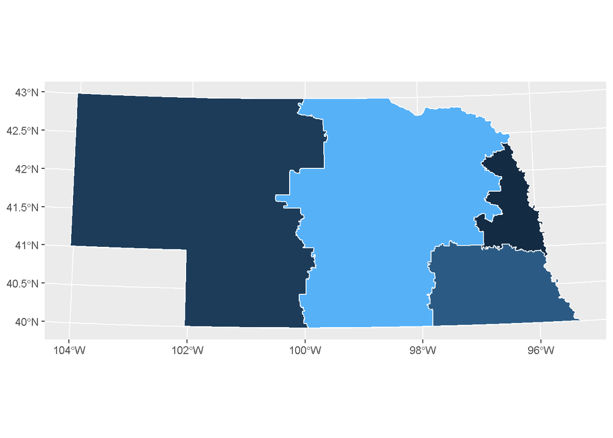

```r
NEshp <- st_read("data/ZipCodesSP_NE/ZipCodesSP.shp") %>%
  dplyr::select(ZCTA5CE10,ALAND10,AWATER10,geometry)
NEshp$group <- 1
NEshp$zip3 <- substr(NEshp$ZCTA5CE10,1,3)
NEshp$zip3 <- as.numeric(NEshp$zip3)

NEshp$zip3[NEshp$zip3 == 570] <- 687
NEshp$zip3[NEshp$zip3 == 515] <- 680
NEshp$zip3[NEshp$zip3 == 665] <- 683
NEshp$zip3[NEshp$zip3 == 807] <- 690
NEshp$zip3[NEshp$zip3 == 820] <- 691

NEzip3_to_RA <- read_excel("data/NEzip3-RA-crosswalk.xlsx")
NEshp <- merge(NEshp,NEzip3_to_RA,by="zip3")
NEshp <-
  group_by(NEshp,RA) %>%
  summarise(estimate=sum(group),do_union = TRUE) %>%
  fill_holes(threshold = units::set_units(135,km^2))

ggplot() +
  geom_sf(data = NEshp, aes(fill = estimate), color = 'white') +
  theme(legend.position = "none")
```

```r
rm(NEzip3_to_RA)
```

3. Put Together A Landscape Sketch

*Create automated in-program engine to trigger rating region contour rendering for policy analysis. More in the next section..*

```r
othercounties_factory <- function(df,name) {
  statedata <- df %>% filter(state == name)
  ref_state <- county2RA %>% filter(state == name)
  if (name != "California") {
    if (length(ref_state$fcounty) != length(unique(ref_state$fcounty))) {
      stop("The County2RA reference file is wrong, examine and take care of duplicates or consistency between files.", call. = FALSE)
    }
    if (unlist(filter(df_validation_census,state==name)["NumCounty"])!=length(ref_state$fcounty)) {
      stop(paste0("Check file consistency. The files may not have complete records for at least ", name),call. = FALSE)
    }
  } else {
    if (length(ref_state$fcounty) != length(unique(ref_state$fcounty)) + 1) {
      stop("The County2RA reference file is wrong, examine and take care of duplicates or consistency between files.", call. = FALSE)
    }
  }
  if (unlist(filter(df_validation_census,state==name)["NumCounty"])!=length(ref_state$fcounty)) {
    stop(paste0("Check file consistency. The files may not have complete records for at least ", name),call. = FALSE)
  }

  statedata <- merge(statedata,dplyr::select(ref_state,-c("state")),
                     by.x=c("GEOID"),by.y=c("fipscode"))
  #print(dim(dplyr::select(statedata,-c("geometry")))[1])
  #print(length(ref_state$fcounty))
  #return(statedata)

  if (dim(dplyr::select(statedata,-c("geometry")))[1] != length(ref_state$fcounty)) {
    stop(paste0("Need to examine merge. The merged file does not have the correct number of counties for ",name))
    cat("\n")
    message(paste0("Processed polygon data ", dim(dplyr::select(statedata,-c("geometry")))[1]))
    cat("\n")
    message(paste0("retrieved reference data ", length(ref_state$fcounty)))
  }
  statedata_merge <- group_by(statedata,ratingarea) %>% summarise(estimate = sum(estimate), do_union = TRUE)

  statedata_merge <- statedata_merge %>% mutate(facet = "merged") %>% dplyr::select("ratingarea","estimate","facet","geometry")
  statedata_unmerge <- statedata %>% dplyr::select(ratingarea,estimate) %>% mutate(facet = "unmerge")
  statedata_output <- rbind(statedata_merge,statedata_unmerge)
  statedata_output$state <- name
  statedata_output <- statedata_output[c("state","ratingarea","facet","estimate","geometry")]
  statedata_output$ratingarea <- as.factor(statedata_output$ratingarea)
  return(statedata_output)
  }

# only1
# states that need to be merged from bespoke shapefiles
special <- c("Alaska","Massachusetts","Nebraska")
# California is still integrated into the list for other states
other <- other[!other %in% special]

MAshp3$do_union <- NULL
colnames(MAshp3)[1] <- "ratingarea"
MAshp3$facet <- "merged"
MAshp3$state <- "Massachusetts"
MAshp3 <- MAshp3[c("state","ratingarea","facet","estimate","geometry")]
MAshp3 <- st_transform(MAshp3,st_crs(states))

NEshp$do_union <- NULL
colnames(NEshp)[1] <- "ratingarea"
NEshp$facet <- "merged"
NEshp$state <- "Nebraska"
NEshp <- NEshp[c("state","ratingarea","facet","estimate","geometry")]
NEshp <- st_transform(NEshp,st_crs(states))

AKshp$do_union <- NULL
colnames(AKshp)[1] <- "ratingarea"
AKshp$facet <- "merged"
AKshp$state <- "Alaska"
AKshp <- AKshp[c("state","ratingarea","facet","estimate","geometry")]
AKshp <- st_transform(AKshp,st_crs(states))
```

## 3. Technical Guide: Pipeline for Cleaning Policy Impact Visualization

Flexibly enabling researchers and policy analysts to explore results ad-hoc, we apply the aforementioned mapping infrastructure in an automated data pipeline, to highlight policy impacts with particular emphasis on outliers and unintended impact of policy interventions in select localities.

1. Tapping into the mapping infrastructure for policy impact illustration

```r
singlestatedata_factory <- function(name) {
  if (name %in% only1) {
    statedata_output <- only1data_factory(counties,name)

  } else if (name %in% other) {
    statedata_output <- othercounties_factory(othercounties,name)

  } else if (name %in% special) {
    if (name == "Nebraska") {
      statedata_output <- NEshp
    } else if (name == "Massachusetts") {
      statedata_output <- MAshp3
    } else if (name == "Alaska") {
      statedata_output <- AKshp
    } else {
      stop("State Input Names are correct, but vector 'special' may be out of order... Abort.", call. = FALSE)
    }

  } else {
    stop("Your input name is out of order, suggest spelling validation", call. = FALSE)

  }
  message(paste0("Completed Assembling State Data : ",name))
  return(statedata_output)
  }

statedata_collecteur <- function(namelist) {
  if (length(namelist)!=length(unique(namelist))) {
    message("Your list has repeated elements, duplicates are deleted and the pipeline flows on from there...")
    namelist <- unique(namelist)
  }

  output <- singlestatedata_factory(namelist[1])
  if (length(namelist) > 51) {
    stop("Your input list has over 51 elements, check your input", call. = FALSE)

  } else if (length(namelist) > 1 ) {
    for (i in 2:length(namelist)) {
      output <- rbind(output,singlestatedata_factory(namelist[i]))
    }
  }
  output$state <- as.factor(output$state)
  output$ratingarea <- as.factor(output$ratingarea)

  return(output)
  }


list <- c("Alabama","Alaska","Arizona","Arkansas","California","Colorado","Connecticut","Delaware",
              "District of Columbia","Florida","Georgia","Hawaii","Idaho","Illinois","Indiana","Iowa","Kansas",
              "Kentucky","Louisiana","Maine","Maryland","Massachusetts","Michigan","Minnesota","Mississippi",
              "Missouri","Montana","Nebraska","Nevada","New Hampshire","New Jersey","New Mexico","New York",
              "North Carolina","North Dakota","Ohio","Oklahoma","Oregon","Pennsylvania","Rhode Island",
              "South Carolina","South Dakota","Tennessee","Texas","Utah","Vermont","Virginia","Washington",
              "West Virginia","Wisconsin","Wyoming")

crudeassemble <- statedata_collecteur(list)
```

2. Allocate policy analysis to localities per research needs
   - Data source not shown here. More on the research process, please see forthcoming briefs.

```r
allra_cont <- left_join(crudeassemble,hpc_data_cont,by=c("state","ratingarea"))
allra_cont <- allra_cont[order(allra_cont$state,allra_cont$ratingarea),]

hpc_data_name_cont <- colnames(allra_cont)[!colnames(allra_cont) %in% c("state","ratingarea","facet","estimate","geometry")]
```

3. Survey result ranges, auto-divide spectrum impact blocks, empower consistent transition between policy intervention scenarios
   - Highlight impact ranges: transform continuous spectrum into harmonized scale of breaks .
   - And Finally, the crescendo arrives as all elements come together in visualization pipeline.

```r
max_setteur <- function(df, data_name_cont) {
  max0 <- max(df[[data_name_cont[1]]],na.rm = TRUE)

  if (length(data_name_cont) > 1) {
    for (i in 2:length(data_name_cont)) {
      max1 <- max(df[[data_name_cont[i]]],na.rm = TRUE)
      if (max1 > max0) {
        max0 <- max1
      }
    }
  }
  max_value <- max0
  return(max_value)
}
min_setteur <- function(df, data_name_cont) {
  min0 <- min(df[[data_name_cont[1]]],na.rm = TRUE)

  if (length(data_name_cont) > 1) {
    for (i in 2:length(data_name_cont)) {
      min1 <- min(df[[data_name_cont[i]]],na.rm = TRUE)
      if (min1 < min0) {
        min0 <- min1
      }
    }
  }
  min_value <- min0
  return(min_value)
}


scale_harmoniser <- function(df, data_name_cont,num_blocks) {
  max_value0 <- max_setteur(df, data_name_cont)
  min_value0 <- min_setteur(df, data_name_cont)
  unit0 <- (max_value0 - min_value0)/(num_blocks+1)


  # Identify breaks, select the lowest number and then pile upward
  if (num_blocks > 1) {
    for (i in 1:num_blocks) {
      higher_one <- min_value0 + unit0 * i
      if (i == 1) {
        stats <- min_value0
      } else {
        stats <- c(stats,higher_one)
      }
    }
  } else {
    stats <- min_value0
  }
  # new breaks
  stats <- c(stats, max_value0)

  if (min_value0 < 0 & max_value0 > 0 & num_blocks > 1) {
    # when numbers cut across 0, select 0 as reference, start with normal cut then locate the two cloest to 0
    i_closest <- which(abs(stats-0)==min(abs(stats-0)))
    num_closest <- stats[i_closest]
    if (num_closest == 0) {
      message("One cut is precisely 0, problem solved.")
    } else {
      distance <- abs(num_closest)/2
      if (num_closest < 0) {
        # Nudge negative to 0, positive further up by half the distance
        i_2nd <- i_closest + 1
        num_2nd <- stats[i_2nd]
        ratio <- abs(num_closest)/abs(num_2nd)
        stats[i_closest] <- 0
        if (ratio > 0.33) {
          stats[i_2nd] <- (num_2nd + distance)
        }
      } else if (num_closest > 0) {
        # Nudge positive to 0, negative further down by half the distance
        i_2nd <- i_closest - 1
        num_2nd <- stats[i_2nd]
        ratio <- abs(num_closest)/abs(num_2nd)
        stats[i_closest] <- 0
        if (ratio > 0.33) {
          stats[i_2nd] <- (num_2nd - distance)
        }
      }
    }
    # by now, the vector should have been rearranged
  }

  # assign labels & colour indicators
    # stats_breaks to be used as break point
    # stats_labels for block labels
    # stats_indiclabels to store indicator used for identifying blocks on the bespoke urban colour scale
  stats_format <- stats
  for (s in 1:length(stats_format)) {
    if (min_value0 >= 0) {
      stats_format[s] <- 100*as.numeric(round(stats_format[s],2))
    } else {
      stats_format[s] <- -100*as.numeric(round(stats_format[s],2))
    }

    if (s == 1) {
      stats_breaks <- stats[s]
    } else if (s == 2) {
      p <- s - 1
      stats_breaks <- c(stats_breaks, stats[s])
      stats_labels <- c(paste(stats_format[p],"% - ", stats_format[s], "%", sep = ""))
      stats_indics <- c(p)
    } else if (s > 2) {
      p <- s - 1
      stats_breaks <- c(stats_breaks, stats[s])
      stats_labels <- c(stats_labels,paste(stats_format[p],"% - ", stats_format[s], "%", sep = ""))
      stats_indics <- c(stats_indics,p)
    }
  }

  # Identify direction of value changes crudely...
  i_zero <- match(0,sort(stats,decreasing = FALSE))
  len_stats <- length(sort(stats,decreasing = FALSE))

  if (min_value0 >= 0) {
    direction_mark <- "Increase"
  } else if (max_value0 < 0) {
    direction_mark <- "Decrease"
  } else if (max_value0 > 0 & min_value0 < 0) {
    if ((i_zero/len_stats) >= 0.5) {
      if ((i_zero/len_stats) > 0.5) {
        direction_mark <- "Decrease"
      } else {
        direction_mark <- "Change"
      }
    } else if ((i_zero/len_stats) < 0.5) {
      direction_mark <- "Increase"
    }
  }

  # assign to break vars and indicator vars
  for (i_col in 1:length(data_name_cont)) {
    col_name <- data_name_cont[i_col]
    df$breakvar <- cut(as.data.frame(df)[,col_name],
                               breaks = stats_breaks,
                               labels = stats_labels,
                               include.lowest = TRUE)
    df$indicvar <- cut(as.data.frame(df)[,col_name],
                               breaks = stats_breaks,
                               labels = stats_indics,
                               include.lowest = TRUE)
    breakvarname <- paste(direction_mark,"_",eval(col_name), sep = "")
    colnames(df)[match("breakvar",colnames(df))] <- breakvarname
    indivarname <- paste0("index_",eval(col_name))
    colnames(df)[match("indicvar",colnames(df))] <- indivarname
  }

  # For consistent and full spectrum of colours, add new column with full set of indivarname
  #df$spectrumColourIndicator <- (as.numeric(rownames(df)))%%num_blocks
  #df$spectrumColourIndicator[df$spectrumColourIndicator==0] <- 8
  #df$spectrumBreak <- stats_labels[df$spectrumColourIndicator]
  df$spectrumBreak <- runif(nrow(df),min_value0,max_value0)
  df$spectrumBreak <- cut(as.data.frame(df)$spectrumBreak,
                          breaks = stats_breaks,
                          labels = stats_labels,
                          include.lowest = TRUE)
  df$stats_values <- rep_len(stats,length.out = nrow(df))
  df <- filter(df,facet=="merged")
  df <- df[,!(names(df) %in% c("facet","estimate","testcol"))]

  return(df)
}
```

**STAY TUNED FOR MORE DATA + POLICY CASES FROM US , CHEERS!**

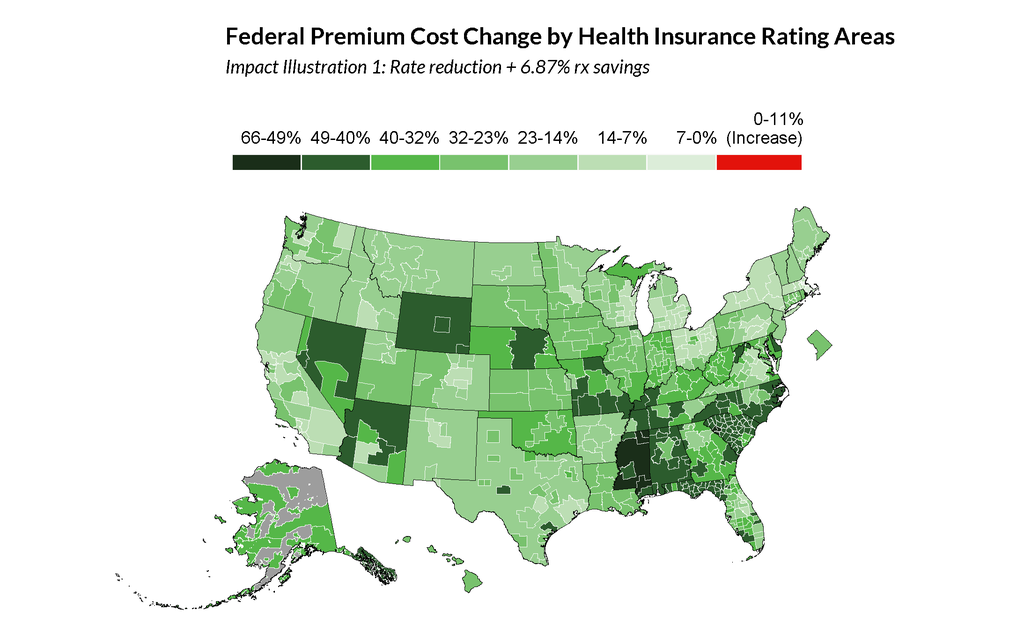

```r
RRMap_factory_Economist <- function(df,frame_border,data_name_cont,which_column,num_blocks,colour_selection) {
  # TO-DO, specify more colours for alternative scenarios with say 8-15 categories specified
  # TO-DO, adjust colour selection based on how many breaks are desired

  # full spectrum of Urban colours - temporarily supports 8 urban colours & black at the end of spectrum
  Urban_blues <- c("#CFE8F3","#A2D4EC","#73BFE2","#46ABDB","#1696D2","#12719E","#0A4C6A","#062635")
  Urban_greys <- c("#F5F5F5","#ECECEC","#E3E3E3","#DCDBDB","#D2D2D2","#9D9D9D","#696969","#353535")
  Urban_reds <- c("#F8D5D4","#F1AAA9","#E9807D","#E25552","#DB2B27","#A4201D","#6E1614","#370B0A")
  Urban_greens <- c("#DCEDD9","#BCDEB4","#98CF90","#78C26D","#55B748","#408941","#2C5C2D","#1A2E19")
  Urban_yellows <- c("#FFF2CF","#FCE39E","#FDD870","#FCCB41","#FDBF11","#E88E2D","#CA5800","#843215")
  Urban_pinks <- c("#F5CBDF","#EB99C2","#E46AA7","#E54096","#EC008B","#AF1F6B","#761548","#351123")

  reasonable_blue <- c("blue","Urban_blues","blues")
  reasonable_grey <- c("grey","Urban_greys","greys")
  reasonable_red <- c("red","Urban_reds","reds")
  reasonable_green <- c("green","Urban_greens","greens")
  reasonable_yellow <- c("yellow","Urban_yellows","yellows")
  reasonable_pink <- c("pink","Urban_pinks","pinks")

  if (missing(colour_selection)) {
    colour_selection <- "blue"
  } else if (!(colour_selection %in% c(reasonable_blue,reasonable_grey,reasonable_red,reasonable_green,reasonable_yellow,reasonable_pink))) {
    message("Colour not specified correctly, defaulting to blue")
    message("Alternatively, rerun function with: blue/grey/red/green/yellow/pink as character in quotes")
    colour_selection <- "blue"
  }
  if (colour_selection %in% reasonable_blue) {
    urban_break_colours <- Urban_blues
  } else if (colour_selection %in% reasonable_grey) {
    urban_break_colours <- Urban_greys
  } else if (colour_selection %in% reasonable_red) {
    urban_break_colours <- Urban_reds
  } else if (colour_selection %in% reasonable_green) {
    urban_break_colours <- Urban_greens
  } else if (colour_selection %in% reasonable_yellow) {
    urban_break_colours <- Urban_yellows
  } else if (colour_selection %in% reasonable_pink) {
    urban_break_colours <- Urban_pinks
  }

  # run scale harmoniser to create breaks in a spectrum appropriate manner
  df <- scale_harmoniser(df,data_name_cont,num_blocks)

  # Identify direction of value changes crudely...
  max_value0 <- max_setteur(df, data_name_cont)
  min_value0 <- min_setteur(df, data_name_cont)

  stats_values <- sort(unique(df$stats_values),decreasing = FALSE)
  i_zero <- match(0,stats_values)
  len_stats <- length(stats_values)

  if (colour_selection %in% reasonable_green) {
    #urban_highlight_colours <- Urban_yellows
    #urban_highlight_colours <- c("#8abbd0")
    urban_highlight_colours <- c("#e3120b")
  } else {
    #urban_highlight_colours <- Urban_greens
    urban_highlight_colours <- c("#e3120b")
  }

  if (min_value0 >= 0) {
    direction_mark <- "Increase"
  } else if (max_value0 < 0) {
    direction_mark <- "Decrease"
    urban_break_colours <- rev(urban_break_colours)
  } else if (max_value0 > 0 & min_value0 < 0) {
    is_breaks_negative <- c(1:(i_zero - 1))
    is_breaks_positive <- c(i_zero:(len_stats-1))

    n_negative <- i_zero - 1
    n_positive <- len_stats - i_zero

    if ((i_zero/len_stats) >= 0.5) {
      if ((i_zero/len_stats) > 0.5) {
        direction_mark <- "Decrease"

        labels_positive <- list()
        for (i in 1:n_positive) {
          start <- 100*as.numeric(round(stats_values[i_zero+i-1],2))
          end <- 100*as.numeric(round(stats_values[(i_zero+i)],2))
          labels_positive[i] <- paste(start,"-", end, "%\n (Increase)", sep = "")
        }

        labels_negative <- list()
        for (i in 1:n_negative) {
          start <- -100*as.numeric(round(stats_values[i],2))
          end <- -100*as.numeric(round(stats_values[i+1],2))
          labels_negative[i] <- paste(start,"-", end, "%", sep = "")
        }
        labels_assemble <- c(unlist(labels_negative),unlist(labels_positive))

      } else {
        direction_mark <- "Change"

        labels_positive <- list()
        for (i in 1:n_positive) {
          start <- 100*as.numeric(round(stats_values[i_zero+i-1],2))
          end <- 100*as.numeric(round(stats_values[(i_zero+i)],2))
          labels_positive[i] <- paste(start,"-", end, "%\n (Increase)", sep = "")
        }

        labels_negative <- list()
        for (i in 1:n_negative) {
          start <- -100*as.numeric(round(stats_values[i],2))
          end <- -100*as.numeric(round(stats_values[i+1],2))
          labels_negative[i] <- paste(start,"-", end, "%\n Decrease", sep = "")
        }
        labels_assemble <- c(unlist(labels_negative),unlist(labels_positive))

      }

      urban_break_colours <- rev(urban_break_colours)
      if (n_negative > 2) {
        colours_negative <- c(urban_break_colours[1],urban_break_colours[2])
        n_negative_remain <- n_negative - 2
        for (i in 1:n_negative_remain) {
          i_assign <- 2 + i + n_positive
          colours_negative <- c(colours_negative,urban_break_colours[i_assign])
        }
      } else if (n_negative == 2) {
        colours_negative <- c(urban_break_colours[1],urban_break_colours[4])
      } else if (n_negative == 1) {
          colours_negative <- c(urban_break_colours[3])
      }

      for (i in 1:n_positive) {
        if (i == 1) {
          colours_positive <- c(urban_highlight_colours[(length(urban_highlight_colours)-7)])
        } else {
          colours_positive <- c(urban_highlight_colours[((length(urban_highlight_colours)-7)-round(1.3*i,digits = 0))],colours_positive)
        }
      }
      urban_break_colours <- c(colours_negative,colours_positive)
    } else if ((i_zero/len_stats) < 0.5) {
      direction_mark <- "Increase"
      #urban_highlight_colours <- rev(urban_highlight_colours)
      labels_positive <- list()
      for (i in 1:n_positive) {
        start <- 100*as.numeric(round(stats_values[i_zero+i-1],2))
        end <- 100*as.numeric(round(stats_values[(i_zero+i)],2))
        labels_positive[i] <- paste(start,"-", end, "%", sep = "")
      }
```

```r
      labels_negative <- list()
      for (i in 1:n_negative) {
        start <- -100*as.numeric(round(stats_values[i],2))
        end <- -100*as.numeric(round(stats_values[i+1],2))
        labels_negative[i] <- paste(start,"-", end, "%\n (Decrease)", sep = "")
      }
      labels_assemble <- c(unlist(labels_negative),unlist(labels_positive))

      if (n_positive > 2) {
        colours_positive <- c(urban_break_colours[(len_stats-2)],urban_break_colours[(len_stats-1)])
        n_positive_remain <- n_positive - 2
        for (i in 1:n_positive_remain){
          i_assign <- len_stats - 2 - i - n_negative
          colours_positive <- c(urban_break_colours[i_assign],colours_positive)
        }
      } else if (n_positive == 2) {
        colours_positive <- c(urban_break_colours[(len_stats-4)],urban_break_colours[(len_stats-1)])
      } else if (n_positive == 1) {
        colours_positive <- c(urban_break_colours[(len_stats-3)])
      }

      for (i in 1:n_negative) {
        if (i == 1) {
          colours_negative <- c(urban_highlight_colours[(length(urban_highlight_colours)-7)])
        } else {
          colours_negative <- c(colours_negative,urban_highlight_colours[((length(urban_highlight_colours)-7)-round(1.3*i,digits = 0))])
        }
      }
      urban_break_colours <- c(colours_negative,colours_positive)
    }
  }

  # Set Data Column
  datadim <- quo(!! sym(data_name_cont[which_column]))
  breakname <- paste(direction_mark,"_",as_name(datadim),sep = "")
  indicname <- paste0("index_",as_name(datadim))

  frame_49_cont <- filter(df,(state != "Alaska" & state != "Hawaii"))
  frame_AK_cont <- filter(df, state == "Alaska")
  frame_HI_cont <- filter(df, state == "Hawaii")
  frame_DC_cont <- filter(df, state == "District of Columbia")
  border_AK <- filter(frame_border,(state =="Alaska")) %>% dplyr::select("state","geometry")
  border_HI <- filter(frame_border,(state =="Hawaii")) %>% dplyr::select("state","geometry")
  border_DC <- filter(frame_border,(state =="District of Columbia")) %>% dplyr::select("state","geometry")
  border_49 <- filter(frame_border,(state !="Alaska" & state !="Hawaii")) %>% dplyr::select("state","geometry")

  # Plot Title, Subtitle, Caption, Bespoke Notes
  scenario_descriptions <- c(
    "Rate reduction + 6.87% rx savings",
    "Rate reduction + 10.61% rx savings",
    "Rate reduction + 6.87% rx savings \ncuts only in rating regions with a single insurer",
    "Rate reduction + 6.87% rx savings \ncuts only in rating regions with two or fewer insurers",
    "Rate reduction + 6.87% rx savings \nwith 10% boost to rural hospitals & physicians",
    "Rate reduction + 6.87% rx savings \nwith 15% boost to all hospitals and 10% to rural physicians",
    "Rate reduction + 6.87% rx savings \nwith 15% boost to urban hospitals, 10% boost to rural physicians,40% boost to rural hospitals."
  )
  list_posadj <- c(3,4,6,7)

  plot_title <- "Federal Premium Cost Change by Health Insurance Rating Areas"
  plot_subtitle <- paste("Impact Illustration ", as.character(which_column), ": ",scenario_descriptions[which_column],sep = "")
  plot_caption <- paste(" Impact Illustrated for ",scenario_descriptions[which_column],sep = "")

  # Empty Map With All Colours in Spectrum Legend
  Map49_Base <-
    ggplot() +
      geom_sf(data = frame_49_cont,aes(fill=spectrumBreak),color="white",lwd=0.15) +
    scale_fill_manual(values = urban_break_colours,
                      guide = guide_legend(
                        direction = "horizontal",
                        keyheight = unit(3, units = "mm"),
                        keywidth = unit(100/length(urban_break_colours), units = "mm"),
                        label.hjust = 1.05,nrow = 1, byrow = TRUE, label.position = "top"),
                      labels=labels_assemble) +
    theme(legend.title = element_blank(),
          legend.position = "top",
          legend.text.align = 0,
          panel.background = element_rect(fill = "transparent",colour = NA),
          plot.title = element_text(hjust = 0,face = "bold",family = "Lato",size = 12),
          plot.subtitle = element_text(hjust = 0, face = "italic",family = "Lato",size = 9.5),
          plot.caption = element_text(hjust = 0, vjust = 1, family = "Lato", size = 8)) +
    labs(subtitle = plot_subtitle, title = plot_title, caption = plot_caption)

  # Retrieving Plot Elements

  spectrum <- gtable_filter(ggplot_gtable(ggplot_build(Map49_Base)),"guide-box")
  caption <- gtable_filter(ggplot_gtable(ggplot_build(Map49_Base)),"caption")
  title <- gtable_filter(ggplot_gtable(ggplot_build(Map49_Base)),"title")

  # Additional Text Object "Source" & "Notes"
  Map49_Base1 <-
    ggplot() +
      geom_sf(data = frame_49_cont,aes(fill=spectrumBreak),color="white",lwd=0.15) +
    theme(legend.title = element_blank(),
          legend.position = "top",
          legend.text.align = 0,
          panel.background = element_rect(fill = "transparent",colour = NA),
          plot.caption = element_text(hjust = 0, vjust = 1, family = "Lato", face = "bold", size = 8)) +
    labs(caption = "Notes: ")

  caption1 <- gtable_filter(ggplot_gtable(ggplot_build(Map49_Base1)),"caption")

  # Plotting 49 with correct projection
  uniquelevel <- sort(unique(as.numeric(na.omit(frame_49_cont[[indicname]]))),decreasing = FALSE)

  Map49_cont <-
    ggplot() +
      geom_sf(data = frame_49_cont,aes(fill=!!as.name(indicname)),color='white',lwd=0.15,na.rm = TRUE)  +
      geom_sf(data = border_49,color = 'black', lwd=0.15, fill=NA) +
      coord_sf(crs = st_crs(2163),xlim = c(-2500000, 2500000),ylim = c(-2300000,730000),datum = NA) +
    scale_fill_manual(values = urban_break_colours[uniquelevel]) +
    theme(legend.position = "none",panel.background = element_rect(fill = "transparent",colour = NA))

  # Plotting Alaska Separately, Alaska Albers Projection CRS 3467
  if (length(unique(as.numeric(na.omit(st_drop_geometry(frame_AK_cont)[[indicname]])))) >= 1) {
    uniquelevel <- sort(unique(as.numeric(na.omit(frame_AK_cont[[indicname]]))), decreasing = FALSE)
  }
```

```r
  MapAK_cont <-
    ggplot() +
      geom_sf(data = frame_AK_cont,aes(fill=!!as.name(breakname)),color='white',size=0.001) +
      geom_sf(data = border_AK,color = 'black', lwd=0.0001, fill=NA) +
      coord_sf(crs = st_crs(3467),xlim = c(-2400000, 1600000),ylim = c(200000,2500000),expand = FALSE, datum = NA) +
      scale_fill_manual(values = urban_break_colours[uniquelevel], na.value="#9d9d9d") +
      theme(legend.position = "none",plot.margin=unit(c(0,0,0,0), "null"),plot.background = element_rect(fill = "transparent",color = NA),
            panel.background=element_rect(fill = "transparent",colour = NA))

  # Plotting Hawaii Separately, Old Hawaii Projection CRS 4135
  uniquelevel <- sort(unique(as.numeric(na.omit(frame_HI_cont[[indicname]]))), decreasing = FALSE)
  MapHI_cont <-
    ggplot() +
      geom_sf(data = frame_HI_cont,aes(fill=!!as.name(breakname)),color='white',size=0.01) +
      geom_sf(data = border_HI,color = 'black', lwd=0.0001, fill=NA) +
      coord_sf(crs = st_crs(4135),xlim = c(-161, -154),ylim = c(18,23),expand = FALSE, datum = NA) +
      scale_fill_manual(values = urban_break_colours[uniquelevel]) +
      theme(legend.position = "none",plot.margin=unit(c(0,0,0,0), "null"),plot.background = element_rect(fill = "transparent",color = NA),
            panel.background=element_rect(fill = "transparent",colour = NA))

  # Plotting DC Separately, use Maryland Projection NAD83 CRS 2248
  uniquelevel <- sort(unique(as.numeric(na.omit(frame_DC_cont[[indicname]]))), decreasing = FALSE)
  MapDC_cont <-
    ggplot() +
      geom_sf(data = frame_DC_cont,aes(fill=!!as.name(breakname)),color='white',size=0.01) +
      geom_sf(data = border_DC,color = 'black', lwd=0.0001, fill=NA) +
      coord_sf(crs = st_crs(2248),datum = NA)  +
      scale_fill_manual(values = urban_break_colours[uniquelevel]) +
      theme(panel.background = element_rect(fill = "transparent",colour = NA),plot.background = element_rect(fill = "transparent",color = NA),
            legend.position = "none",plot.margin = unit(c(0,0,0,0), "null"))

  # Knit n Mold - through customised annotation option
  map <-
    Map49_cont +
  annotation_custom(grob = ggplotGrob(MapAK_cont),xmin = -3300000,xmax = -3300000 + (1550000 - (-3400000))/2,ymin = -2590000,ymax = -2590000 + (2000000 + 800000)/2) +
    annotation_custom(grob = ggplotGrob(MapHI_cont),xmin = -1250000,xmax = -1250000 + (-154 - (-164)) * 135000, ymin = -2450000,ymax = -2450000 + (23 - 18) * 135000)+
    annotation_custom(grob = ggplotGrob(MapDC_cont),xmin = 2300000, xmax = 2300000 + (78-76) * 135000, ymin = -500000,ymax = -500000 + (40-38) * 135000)

  # Plot Shift Orientation From SouthWest
  if (which_column %in% list_posadj) {
    y_pos <- 0.036
    input_height <- 0.05
  } else {
    y_pos <- 0.05
    input_height <- 0.08
  }

  map <-
    ggdraw() +
      draw_plot(title,x=0.22,y=0.85,width = 0.8,height = 0.12) +
      draw_plot(spectrum, x=0,y=0.73,width = 1,height = 0.1) +
      draw_plot(map, x=0,y=0.02,width = 1,height = 0.7)

  return(map)
}
```

#### Share: